# datavisualization-explanatory slides

## How to increase the Consumers of the service?

> The main target of the investigation is to reach out for maximum number of consumers possible  
> The distribution of consumers through age groups, genders, days of the week should be investigated further

### How Gender affect the numbers?

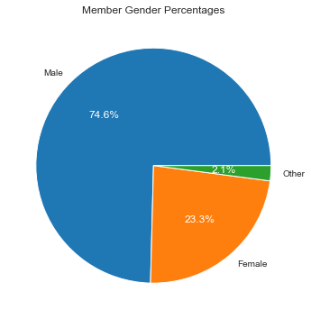

### How the users vary through the group ages?

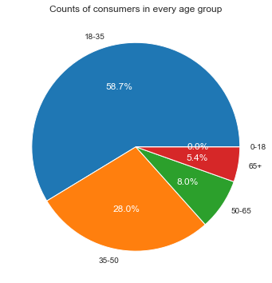

> More than half of the consumers aged between 18-35 with a percentage of 58.7 of our records  
> Comes next people within 35-50 years old with a percentage of 28%  
> Customers in the range of 50-65 come next with 8 % and 65+ years old with 5.4%  
> With the total absence of teenagers below 18 years old with 0%

### How the day of week affect number of trips done?

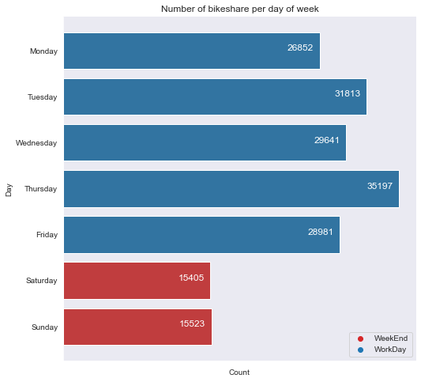

> In the month of february 2019 there were a total trips of 35197 on Thursday as the most number in the days of the week  
> With Tuesday coming in next with 31813 trips  
> Wednesday and Friday are close on the list with 29641 and 28981 trips respectively  
> Monday with 26852 trips in 5th place  
> Surprising that weekend days goes down as 15523 and 15405 trips for Sunday and Saturday respectively

### How are the daily trips distributed according to time of the day?

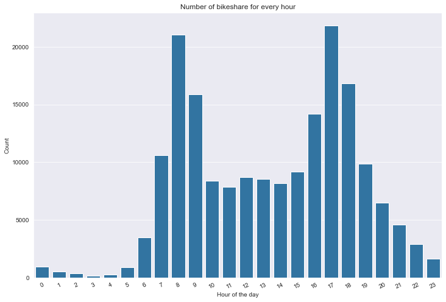

> Trips are distributed through the day as a bimodal distribution with two extreme peaks at 8am and 17 pm, That distribution is constant through week days that may be due to people using the service to go to and back from work  
> With Weekends distribution is normally distributed with no peaks at a certain hour

### Is every user a subscriber?

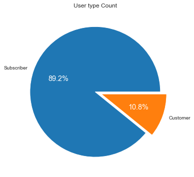

> Almost 90% of the users are subscribers with a small percentage of users are casual customers

### The effect of geographical position on the usage of the service

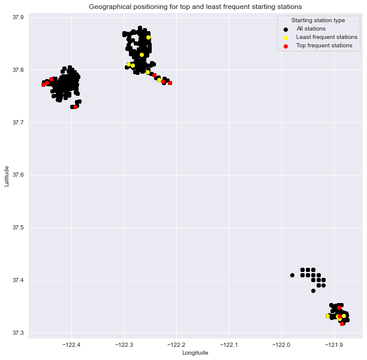

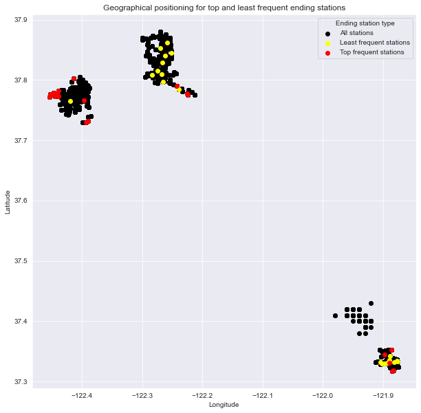

> Here we will dive deeper into the aforementioned numbers to analyse more the areas to target

### Gender vs Age groups distribution

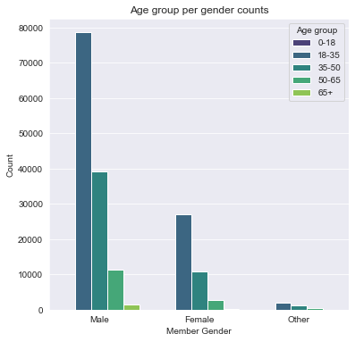

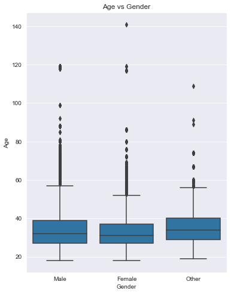

> Further analysis of the age of consumers from each gender  
> each group show almost the same mean age of 30 years old with females are slightly younger than males  
> And then interquartile range of ~27-39 for men and ~27-37 for women means that that there is little to no action should be taken based on the age analysis of each gender

### Count of trips each day for each gender

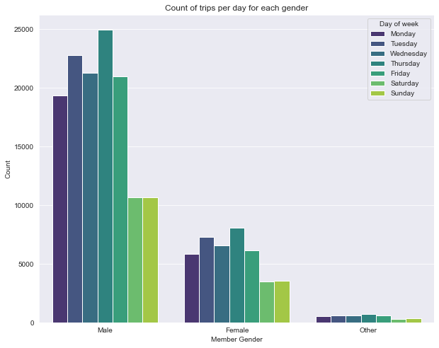

> Further investigation of the number of trips for each gender based on day of week  
> This only solidates the previous results that Thursday is the most busy day and weekend days are low in order  
> Both genders show the same behaviour in terms of distribution with different magnitudes

### Trip duration analysis for each gender in each age group

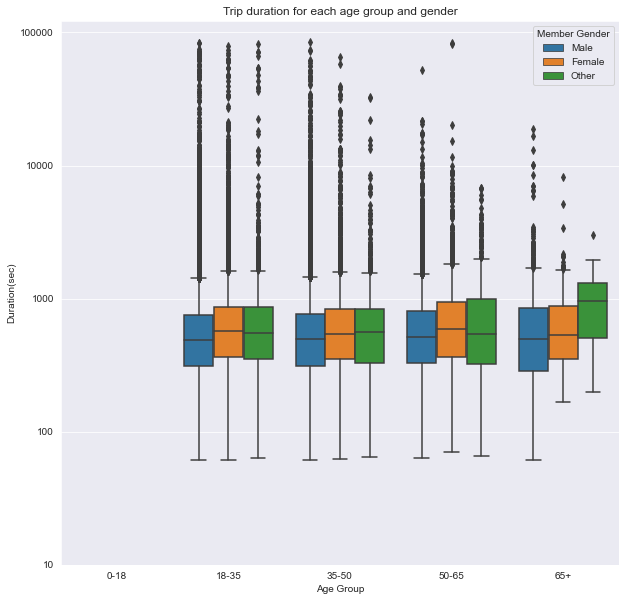

> Trip analysis for each gender in each age group show slight increase in mean trip duration through the group ages for both genders especially females with the highest values coming in the age group of 50-65  
> Females spend more time using our service in average, That may be due to lower velocity on the bike(That could be investigated but it won't differ much in the study)

### Trip duration Analysis for each gender and user types

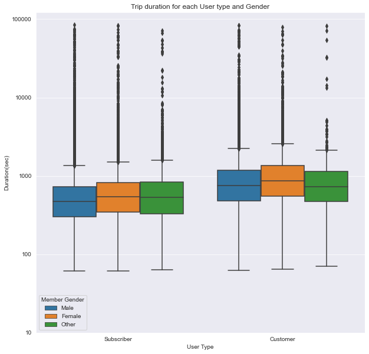

> From that graph it shows higher values for trip durations for casual customers than subscribers in all genders  
> But with the small percentage of the casual customers compared to subscribers that would make a little difference

## Recommendations:

> - Company should target to increase the users from the **females** of all ages
> - **Teenagers of below 18 years old** should be targeted and explore the cause of their complete absence in the data set
> - Weekends should be targeted more to increase the usage of service
> - Eastern and central parts of the city should be targeted to increase the usage of the service